# Data Science Capstone Project

Uzair Zaidi

2024-12-23

# 1 Introduction and learning objectives

The purpose of this exercise is to build an estimation engine to guide investment decisions in London house market. You will first build machine learning algorithms (and tune them) to estimate the house prices given variety of information about each property. Then, using your algorithm, you will choose 200 houses to invest in out of about 2000 houses on the market at the moment.

**Learning objectives**

1. Using different data mining algorithms for prediction.
2. Dealing with large data sets
3. Tuning data mining algorithms
4. Interpreting data mining algorithms and deducing importance of variables
5. Using results of data mining algorithms to make business decisions

# 2 Load data

There are two sets of data, i) training data that has the actual prices ii) out of sample data that has the asking prices. Load both data sets.

Make sure you understand what information each column contains. Note that not all information provided might be useful in predicting house prices, but do not make any assumptions before you decide what information you use in your prediction algorithms.

```r
# Read and clean data
train_data <- read.csv("training_data_assignment_with_prices.csv") %>% clean_names()
test_data <- read.csv("test_data_assignment.csv") %>% clean_names()

# Inspect data structure
str(train_data)
```

```
## 'data.frame':    13998 obs. of  37 variables:
##  $ id                          : int  2 3 4 5 7 8 9 10 11 12 ...
##  $ date                        : chr  "2019-11-01" "2019-08-08" "2019-04-23" "2019-07-05" ...
##  $ postcode                    : chr  "SW8 1UY" "TW10 5DF" "TW14 9QY" "E12 5AX" ...
##  $ property_type               : chr  "F" "F" "S" "F" ...
##  $ whether_old_or_new          : chr  "N" "N" "N" "N" ...
##  $ freehold_or_leasehold       : chr  "L" "L" "F" "L" ...
##  $ address1                    : chr  "STAMFORD BUILDINGS" "73" "199" "72A" ...
##  $ address2                    : chr  "FLAT 8" NA NA NA ...
##  $ address3                    : chr  "SOUTH LAMBETH ROAD" "SHEEN COURT" "HATTON ROAD" "DURHAM ROAD" ...
##  $ town                        : chr  NA NA NA "MANOR PARK" ...
##  $ local_aut                   : chr  "LONDON" "RICHMOND" "FELTHAM" "LONDON" ...
##  $ county                      : chr  "LAMBETH" "RICHMOND UPON THAMES" "HOUNSLOW" "NEWHAM" ...
##  $ postcode_short              : chr  "SW8" "TW10" "TW14" "E12" ...
##  $ current_energy_rating       : chr  "E" "D" "D" "E" ...
```

[output cut: 23 more lines]

```r
str(test_data)
```

```
## 'data.frame':    1999 obs. of  37 variables:
##  $ id                          : int  14434 12562 8866 10721 1057 1527 13961 12108 9363 1155 ...
##  $ date                        : logi  NA NA NA NA NA NA ...
##  $ postcode                    : logi  NA NA NA NA NA NA ...
##  $ property_type               : chr  "D" "F" "F" "S" ...
##  $ whether_old_or_new          : chr  "N" "N" "N" "N" ...
##  $ freehold_or_leasehold       : chr  "F" "L" "L" "F" ...
##  $ address1                    : logi  NA NA NA NA NA NA ...
##  $ address2                    : logi  NA NA NA NA NA NA ...
##  $ address3                    : logi  NA NA NA NA NA NA ...
##  $ town                        : chr  NA NA NA NA ...
##  $ local_aut                   : logi  NA NA NA NA NA NA ...
##  $ county                      : logi  NA NA NA NA NA NA ...
##  $ postcode_short              : chr  "N14" "HA0" "E3" "HA2" ...
##  $ current_energy_rating       : chr  "D" "C" "D" "D" ...
```

[output cut: 23 more lines]

```r
# Fix dates
if("date" %in% colnames(train_data)) {
  train_data <- train_data %>% mutate(date = as.Date(date, "%Y-%m-%d"))
}
if("date" %in% colnames(test_data)) {
  test_data <- test_data %>% mutate(date = as.Date(date, "%Y-%m-%d"))
}

# Convert character variables to factor
train_data <- train_data %>%
  mutate(across(where(is.character), as.factor))

test_data <- test_data %>%
  mutate(across(where(is.character), as.factor))

# Drop columns if they are not useful or have too many missing values
train_data <- train_data %>% select(-address2, -town, -date)
test_data <- test_data %>% select(-address2, -town, -date)

# Impute missing values in `population` if it exists
if("population" %in% colnames(train_data)){
  train_data$population[is.na(train_data$population)] <- median(train_data$population, na.rm = TRUE)
}
if("population" %in% colnames(test_data)){
  test_data$population[is.na(test_data$population)] <- median(test_data$population, na.rm = TRUE)
}

# Check missing values
cat("Missing Values in Train Data:\n")
```

```
## Missing Values in Train Data:
```

```r
print(sapply(train_data, function(x) sum(is.na(x))))
```

```
##                           id                     postcode
##                            0                            0
##                property_type           whether_old_or_new
##                            0                            0
##        freehold_or_leasehold                     address1
##                            0                            0
##                     address3                    local_aut
##                            0                            0
##                       county               postcode_short
##                            0                            0
##        current_energy_rating             total_floor_area
##                            0                            0
##       number_habitable_rooms        co2_emissions_current
##                            0                            0
##      co2_emissions_potential   energy_consumption_current
##                            0                            0
## energy_consumption_potential           windows_energy_eff
##                            0                            0
##                       tenure                     latitude
##                            0                            0
##                    longitude                   population
##                            0                            0
##                     altitude                  london_zone
##                            0                            0
##              nearest_station                water_company
##                            0                            0
##               average_income                     district
##                            0                            0
##                        price      type_of_closest_station
##                            0                            0
##               num_tube_lines               num_rail_lines
##                            0                            0
##         num_light_rail_lines          distance_to_station
##                            0                            0
```

```r
cat("\nMissing Values in Test Data:\n")
```

```
##
## Missing Values in Test Data:
```

```r
print(sapply(test_data, function(x) sum(is.na(x))))
```

```
##                           id                     postcode
##                            0                         1999
##                property_type           whether_old_or_new
##                            0                            0
##        freehold_or_leasehold                     address1
##                            0                         1999
##                     address3                    local_aut
##                         1999                         1999
##                       county               postcode_short
##                         1999                            0
##        current_energy_rating             total_floor_area
##                            0                            0
##       number_habitable_rooms        co2_emissions_current
##                            0                            0
##      co2_emissions_potential   energy_consumption_current
##                            0                            0
## energy_consumption_potential           windows_energy_eff
##                            0                            0
##                       tenure                     latitude
##                            0                            0
##                    longitude                   population
##                            0                            0
##                     altitude                  london_zone
##                            0                            0
##              nearest_station                water_company
##                            0                            0
##               average_income                     district
##                            0                            0
##      type_of_closest_station               num_tube_lines
##                            0                            0
##               num_rail_lines         num_light_rail_lines
##                            0                            0
##          distance_to_station                 asking_price
##                            0                            0
```

```r
#let's do the initial split
set.seed(123)
train_test_split <- initial_split(train_data, prop = 0.75)
training_set <- training(train_test_split)
validation_set <- testing(train_test_split)
validation_set_original <- validation_set %>% select(everything())

# Check dimensions
dim(training_set)
```

```
## [1] 10498    34
```

```r
dim(validation_set)
```

```
## [1] 3500   34
```

# 3 Visualize data

Visualize and examine the data. What plots could be useful here? What do you learn from these visualizations?

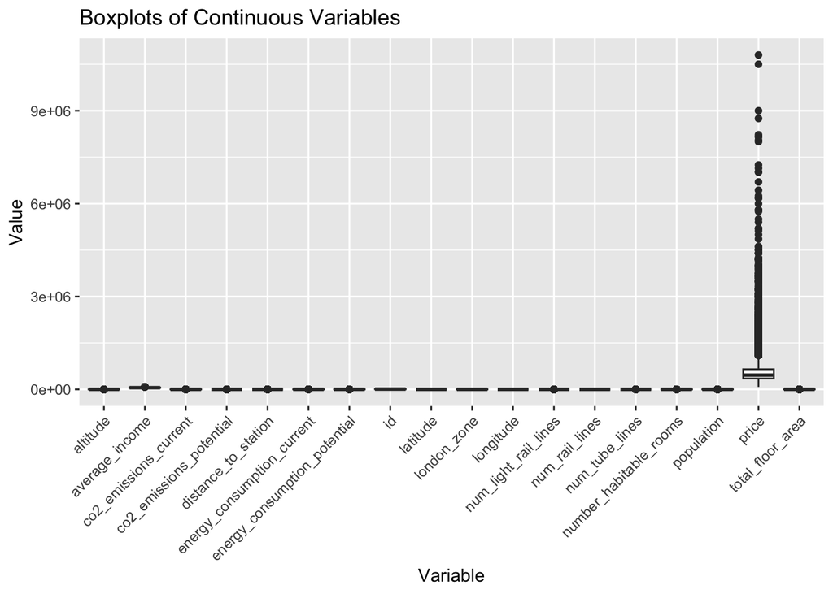

```r
# Boxplots of continuous variables
train_data %>%
  select(where(is.numeric)) %>%
  pivot_longer(cols = everything(), names_to = "Variable", values_to = "Value") %>%
  ggplot(aes(x = Variable, y = Value)) +
  geom_boxplot() +
  theme(axis.text.x = element_text(angle = 45, hjust = 1)) +
  labs(title = "Boxplots of Continuous Variables")
```

Estimate a correlation table between prices and other continuous variables. What do you glean from the correlation table?

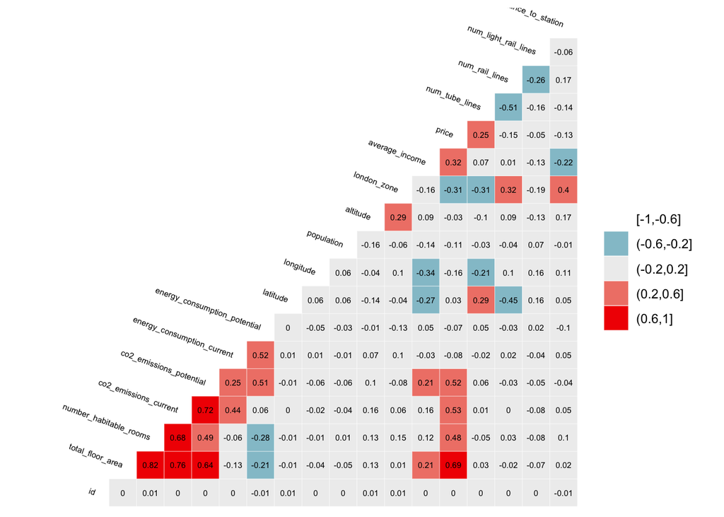

```r
# produce a correlation table using GGally::ggcor()
# this takes a while to plot
# keep Y variable last

train_data %>%
  ggcorr(method = c("pairwise", "pearson"), layout.exp = 2,label_round=2, label = TRUE,label_size = 2,hjust = 1,nbreaks = 5,size = 2,angle = -20)
```

```r
numeric_data <- train_data %>% select(where(is.numeric))

# Compute correlation matrix
cor_matrix <- cor(numeric_data, use = "pairwise.complete.obs", method = "pearson")

# Extract correlations with 'price'
price_corr <- cor_matrix["price", ]

# Sort by absolute correlation, descending order
top_vars <- names(sort(abs(price_corr), decreasing = TRUE))

# Remove 'price' itself
top_vars <- top_vars[top_vars != "price"]

# Print top correlated variables
print(top_vars)
```

```
##  [1] "total_floor_area"             "co2_emissions_current"
##  [3] "co2_emissions_potential"      "number_habitable_rooms"
##  [5] "average_income"               "london_zone"
##  [7] "num_tube_lines"               "longitude"
##  [9] "num_rail_lines"               "distance_to_station"
## [11] "population"                   "energy_consumption_current"
## [13] "energy_consumption_potential" "num_light_rail_lines"
## [15] "altitude"                     "latitude"
## [17] "id"
```

```r
my_formula <- as.formula(
  paste("price ~", paste(top_vars, collapse = " + "))
)
```

# 4 Fit a linear regression model

To help you get started I build a linear regression model below. I chose a subset of the features with no particular goal. You can (and should) add more variables and/or choose variable selection methods if you want.

```r
set.seed(123)
control <- trainControl(method="cv", number=5, verboseIter=TRUE)

model_lm <- train(
  my_formula,
  data = training_set,
  method = "lm",
  trControl = control
)
summary(model_lm)
```

```
##
## Call:
## lm(formula = .outcome ~ ., data = dat)
##
## Residuals:
##      Min       1Q   Median       3Q      Max
## -1856732  -126667    -6307   102264  7144162
##
## Coefficients:
##                                Estimate Std. Error t value Pr(>|t|)
## (Intercept)                  -8.163e+06  2.411e+06  -3.386 0.000712 ***
## total_floor_area              8.672e+03  2.032e+02  42.671  < 2e-16 ***
## co2_emissions_current        -2.255e+04  5.148e+03  -4.381 1.19e-05 ***
## co2_emissions_potential       6.991e+04  7.134e+03   9.800  < 2e-16 ***
## number_habitable_rooms       -5.158e+04  3.618e+03 -14.255  < 2e-16 ***
## average_income                6.936e+00  4.364e-01  15.892  < 2e-16 ***
## london_zone                  -8.275e+04  2.752e+03 -30.067  < 2e-16 ***
## num_tube_lines                8.561e+04  5.521e+03  15.506  < 2e-16 ***
## longitude                    -1.617e+05  2.147e+04  -7.534 5.33e-14 ***
## num_rail_lines                2.175e+04  8.380e+03   2.596 0.009455 **
## distance_to_station           7.725e+03  8.710e+03   0.887 0.375144
## population                   -7.762e+02  7.325e+01 -10.597  < 2e-16 ***
## energy_consumption_current    5.818e+02  8.625e+01   6.746 1.60e-11 ***
## energy_consumption_potential -9.565e+02  1.094e+02  -8.746  < 2e-16 ***
## num_light_rail_lines         -6.060e+03  8.541e+03  -0.710 0.478006
## altitude                     -1.182e+03  1.320e+02  -8.953  < 2e-16 ***
## latitude                      1.566e+05  4.671e+04   3.352 0.000806 ***
## id                            2.919e-01  6.803e-01   0.429 0.667899
## ---
## Signif. codes:  0 '***' 0.001 '**' 0.01 '*' 0.05 '.' 0.1 ' ' 1
##
## Residual standard error: 321100 on 10480 degrees of freedom
## Multiple R-squared:  0.6334, Adjusted R-squared:  0.6328
## F-statistic:  1065 on 17 and 10480 DF,  p-value: < 2.2e-16
```

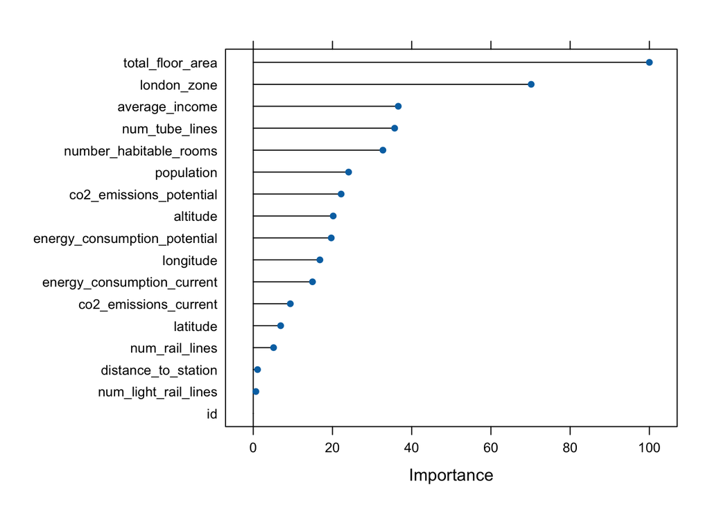

```r
# Variable importance
importance_lm <- varImp(model_lm, scale=TRUE)
plot(importance_lm)
```

## 4.1 Predict the values in testing and out of sample data

Below I use the predict function to test the performance of the model in testing data and summarize the performance of the linear regression model. How can you measure the quality of your predictions?

```r
# We can predict the testing values
predictions_lm <- predict(model_lm, validation_set)
lm_results <- data.frame(
  RMSE = RMSE(predictions_lm, validation_set$price),
  R2 = R2(predictions_lm, validation_set$price)
)
lm_results
```

```
##       RMSE        R2
## 1 300221.5 0.6194829
```

```r
colnames(test_data)
```

```
##  [1] "id"                           "postcode"
##  [3] "property_type"                "whether_old_or_new"
##  [5] "freehold_or_leasehold"        "address1"
##  [7] "address3"                     "local_aut"
##  [9] "county"                       "postcode_short"
## [11] "current_energy_rating"        "total_floor_area"
## [13] "number_habitable_rooms"       "co2_emissions_current"
## [15] "co2_emissions_potential"      "energy_consumption_current"
## [17] "energy_consumption_potential" "windows_energy_eff"
## [19] "tenure"                       "latitude"
## [21] "longitude"                    "population"
## [23] "altitude"                     "london_zone"
## [25] "nearest_station"              "water_company"
## [27] "average_income"               "district"
## [29] "type_of_closest_station"      "num_tube_lines"
## [31] "num_rail_lines"               "num_light_rail_lines"
## [33] "distance_to_station"          "asking_price"
```

```r
head(predictions_lm)
```

```
##          1          2          3          4          5          6
##  596449.45  116069.19 1370241.01  483970.23  -35500.59  248072.87
```

# 5 Fit a tree model

Next I fit a tree model using the same subset of features. Again you can (and should) add more variables and tune the parameter of your tree to find a better fit.

Compare the performance of the linear regression model with the tree model; which one performs better? Why do you think that is the case?

```r
### Feature Engineering ###
training_set <- training_set %>% mutate(log_price = log(price))
validation_set <- validation_set %>% mutate(log_price = log(price))

# rooms_per_area
training_set <- training_set %>%
  mutate(rooms_per_area = number_habitable_rooms / (total_floor_area + 1))
validation_set <- validation_set %>%
  mutate(rooms_per_area = number_habitable_rooms / (total_floor_area + 1))

# distance_to_center
center_lat <- 51.5074
center_lon <- -0.1278
training_set <- training_set %>%
  mutate(distance_to_center = sqrt((latitude - center_lat)^2 + (longitude - center_lon)^2))
validation_set <- validation_set %>%
  mutate(distance_to_center = sqrt((latitude - center_lat)^2 + (longitude - center_lon)^2))

# log_distance_station
training_set <- training_set %>%
  mutate(log_distance_station = log(distance_to_station + 1))
validation_set <- validation_set %>%
  mutate(log_distance_station = log(distance_to_station + 1))

# log_energy_consumption_current
training_set <- training_set %>%
  mutate(log_energy_consumption_current = log(energy_consumption_current + 1))
validation_set <- validation_set %>%
  mutate(log_energy_consumption_current = log(energy_consumption_current + 1))

# Check that these variables exist
missing_in_train <- setdiff(top_vars, colnames(training_set))
if(length(missing_in_train) > 0){
  stop("The following variables are missing in training_set: ", paste(missing_in_train, collapse=", "))
}

# final_vars includes chosen predictors only (no log_price as predictor)
final_vars <- top_vars  # only the top_vars, exclude "log_price" from predictors


# Include log_price separately as the outcome, not as a predictor
training_set <- training_set %>% select(all_of(final_vars), log_price)
validation_set <- validation_set %>% select(all_of(final_vars), log_price)

validation_set$price <- validation_set_original$price
validation_set$price <- as.numeric(as.character(validation_set$price))
```

```r
model2_tree <- train(
  log_price ~ .,
  data = training_set,
  method = "rpart",
  trControl = control,
  tuneLength=10
    )
#You can view how the tree performs
model2_tree$results
```

```
##            cp      RMSE  Rsquared       MAE      RMSESD  RsquaredSD       MAESD
## 1  0.01203091 0.3264822 0.6497723 0.2447397 0.008035780 0.010783306 0.004958603
## 2  0.01321955 0.3302517 0.6417467 0.2482949 0.009893681 0.010931230 0.007833492
## 3  0.01625741 0.3353525 0.6305954 0.2521081 0.008305170 0.006619114 0.005960246
## 4  0.01773023 0.3402093 0.6198743 0.2563641 0.010340188 0.006797864 0.007233046
## 5  0.02675837 0.3550469 0.5862056 0.2672452 0.012882989 0.015697599 0.007187799
## 6  0.03567651 0.3797057 0.5256443 0.2874649 0.004974738 0.026869341 0.004290177
## 7  0.03712706 0.3827724 0.5179490 0.2902153 0.010919595 0.032077152 0.007181254
## 8  0.06682089 0.4019541 0.4688434 0.3049598 0.021299710 0.043126406 0.010729072
## 9  0.08025054 0.4374502 0.3706220 0.3291846 0.011777038 0.027888028 0.008952946
## 10 0.35693187 0.4657619 0.3512090 0.3499110 0.049750087 0.003734020 0.037819473
```

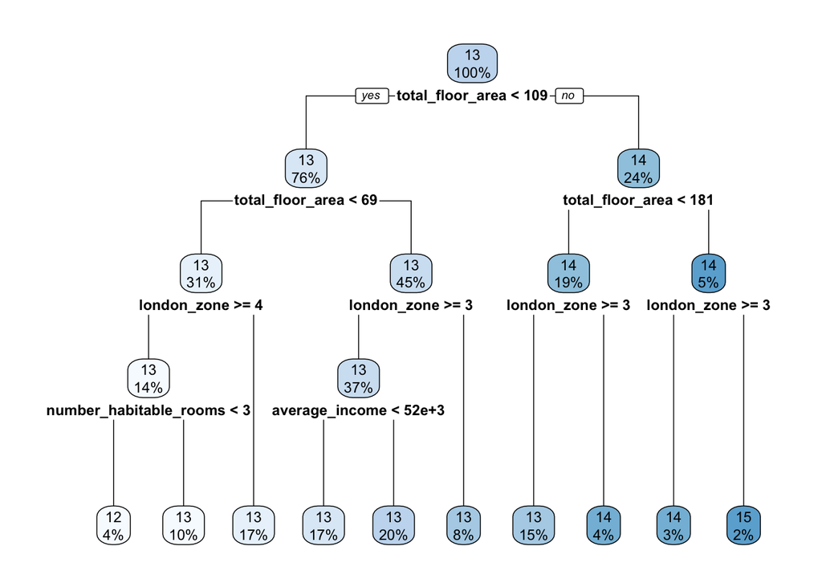

```r
#You can view the final tree
rpart.plot(model2_tree$finalModel)
```

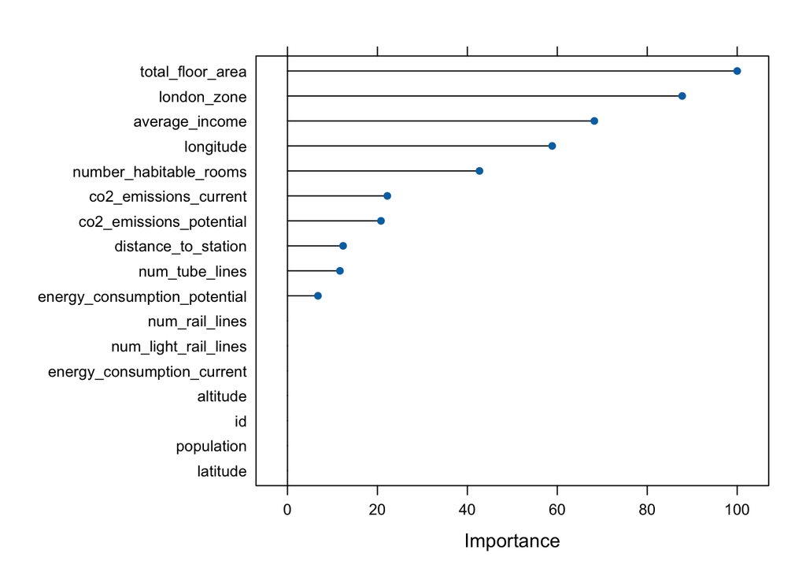

```r
#you can also visualize the variable importance
importance <- varImp(model2_tree, scale=TRUE)
plot(importance)
```

```r
str(validation_set$price)
```

```
##  num [1:3500] 499950 259999 1440000 440000 207000 ...
```

# 6 Other algorithms

Use at least two other algorithms to predict prices. Don’t forget to tune the parameters of these algorithms. And then compare the performances of your algorithms to linear regression and trees.

```r
## RANDOM FOREST ##


set.seed(123)
control_min <- trainControl(method = "cv", number = 2, savePredictions = "final")

tune_grid_expanded <- expand.grid(
  mtry = c(3,5,7),
  splitrule = "variance",
  min.node.size = c(5,10)
)

# Using entire Training Set
model_rf_min <- train(
  log_price ~ ., # Excluding price, only use predictors and log_price as the target
  data = training_set,
  method = "ranger",
  trControl = control_min,
  tuneGrid = tune_grid_expanded,
  num.trees = 200,
  importance = 'impurity'
)

print(model_rf_min)
```

```
## Random Forest
##
## 10498 samples
##    17 predictor
##
## No pre-processing
## Resampling: Cross-Validated (2 fold)
## Summary of sample sizes: 5247, 5251
## Resampling results across tuning parameters:
##
##   mtry  min.node.size  RMSE       Rsquared   MAE
##   3      5             0.2344131  0.8266795  0.1660637
##   3     10             0.2349537  0.8266979  0.1662316
##   5      5             0.2305677  0.8282267  0.1636323
##   5     10             0.2312725  0.8273094  0.1638984
##   7      5             0.2295144  0.8284565  0.1629224
##   7     10             0.2301797  0.8275290  0.1632843
##
## Tuning parameter 'splitrule' was held constant at a value of variance
## RMSE was used to select the optimal model using the smallest value.
## The final values used for the model were mtry = 7, splitrule = variance
##  and min.node.size = 5.
```

```r
# Reintroduces the original price from validation_set_original
validation_set$price <- validation_set_original$price

# Converts to numeric
validation_set$price <- as.numeric(as.character(validation_set$price))

### Evaluate on validation ###
predictions_log <- predict(model_rf_min, validation_set)
predictions <- exp(predictions_log)

rf_results <- data.frame(
  RMSE = RMSE(predictions, validation_set$price),
  R2 = R2(predictions, validation_set$price)
)
print(rf_results)
```

```
##       RMSE        R2
## 1 192548.7 0.8559675
```

```r
# 2. XGBoost Model
##############################
set.seed(123)
control_xgb <- trainControl(
  method = "cv",
  number = 5,
  verboseIter = TRUE,     # See progress
  savePredictions = "final"
)

# Tuning grid for XGBoost:
# - nrounds: number of boosting iterations
# - max_depth: depth of each tree
# - eta: learning rate
# - gamma: minimum loss reduction required to make a split
# - colsample_bytree: subsample ratio of columns
# - min_child_weight: minimum sum of instance weight needed in a child

tune_grid_xgb <- expand.grid(
  nrounds = c(100, 200),
  max_depth = c(3, 5),
  eta = c(0.1, 0.05),
  gamma = c(0, 1),
  colsample_bytree = c(0.8),
  min_child_weight = c(1),
  subsample = c(0.8)
)

model_xgb <- train(
  log_price ~ .,
  data = training_set,
  method = "xgbTree",
  trControl = control_xgb,
  tuneGrid = tune_grid_xgb,
  metric = "RMSE"
)
```

[output not shown]

```r
print(model_xgb)
```

```
## eXtreme Gradient Boosting
##
## 10498 samples
##    17 predictor
##
## No pre-processing
## Resampling: Cross-Validated (5 fold)
## Summary of sample sizes: 8398, 8399, 8398, 8399, 8398
## Resampling results across tuning parameters:
##
##   eta   max_depth  gamma  nrounds  RMSE       Rsquared   MAE
##   0.05  3          0      100      0.2506319  0.8173889  0.1843630
##   0.05  3          0      200      0.2282996  0.8289249  0.1627127
##   0.05  3          1      100      0.2507433  0.8168537  0.1843497
##   0.05  3          1      200      0.2306521  0.8258001  0.1643641
##   0.05  5          0      100      0.2406029  0.8306252  0.1777967
##   0.05  5          0      200      0.2216291  0.8386095  0.1572376
##   0.05  5          1      100      0.2429248  0.8267350  0.1792632
##   0.05  5          1      200      0.2272544  0.8308044  0.1615237
##   0.10  3          0      100      0.2300764  0.8261727  0.1640507
##   0.10  3          0      200      0.2265625  0.8313113  0.1615269
##   0.10  3          1      100      0.2309244  0.8252323  0.1650160
##   0.10  3          1      200      0.2290875  0.8277446  0.1636182
##   0.10  5          0      100      0.2233274  0.8360805  0.1588920
##   0.10  5          0      200      0.2209575  0.8395106  0.1568756
##   0.10  5          1      100      0.2270969  0.8309568  0.1619218
##   0.10  5          1      200      0.2263961  0.8317862  0.1613808
##
## Tuning parameter 'colsample_bytree' was held constant at a value of 0.8
##
## Tuning parameter 'min_child_weight' was held constant at a value of 1
##
## Tuning parameter 'subsample' was held constant at a value of 0.8
## RMSE was used to select the optimal model using the smallest value.
## The final values used for the model were nrounds = 200, max_depth = 5, eta
##  = 0.1, gamma = 0, colsample_bytree = 0.8, min_child_weight = 1 and subsample
##  = 0.8.
```

```r
### Evaluate on validation set ###
predictions_log_xgb <- predict(model_xgb, validation_set)
predictions_xgb <- exp(predictions_log_xgb) # Predictions to original scale

xgb_results <- data.frame(
  RMSE = RMSE(predictions_xgb, validation_set$price),
  R2 = R2(predictions_xgb, validation_set$price)
)

print(xgb_results)
```

```
##       RMSE       R2
## 1 178406.3 0.867042
```

```r
### Tuning ###
# Increased nrounds and tried lowering eta
# Tried different min_child_weight / colsample_bytree values
```

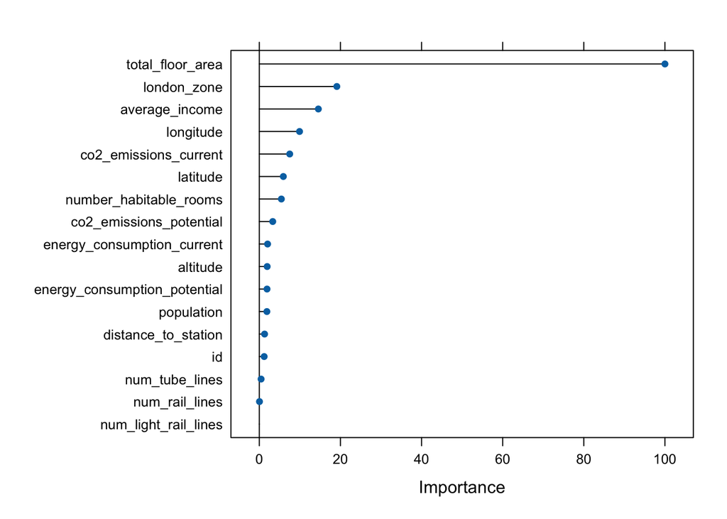

```r
importance <- varImp(model_xgb, scale=TRUE)
plot(importance)
```

```r
##Gradient Boosting Machine##

set.seed(123)
control_gbm <- trainControl(
  method = "cv",
  number = 5,
  savePredictions = "final",
  verboseIter = TRUE
)

tune_grid_gbm <- expand.grid(
  interaction.depth = c(3, 5),
  n.trees = c(100, 200),
  shrinkage = c(0.1, 0.05),     # Learning rate
  n.minobsinnode = c(5, 10)
)

model_gbm <- train(
  log_price ~ .,
  data = training_set,
  method = "gbm",
  trControl = control_gbm,
  tuneGrid = tune_grid_gbm,
  metric = "RMSE",
  verbose = FALSE
)
print(model_gbm)
```

```
## Stochastic Gradient Boosting
##
## 10498 samples
##    17 predictor
##
## No pre-processing
## Resampling: Cross-Validated (5 fold)
## Summary of sample sizes: 8398, 8399, 8398, 8399, 8398
## Resampling results across tuning parameters:
##
##   shrinkage  interaction.depth  n.minobsinnode  n.trees  RMSE       Rsquared
##   0.05       3                   5              100      0.2480364  0.8055051
##   0.05       3                   5              200      0.2332312  0.8216953
##   0.05       3                  10              100      0.2483195  0.8047143
##   0.05       3                  10              200      0.2334395  0.8212024
##   0.05       5                   5              100      0.2376546  0.8172714
##   0.05       5                   5              200      0.2287896  0.8280184
##   0.05       5                  10              100      0.2375778  0.8173591
##   0.05       5                  10              200      0.2286296  0.8282854
##   0.10       3                   5              100      0.2332263  0.8214739
##   0.10       3                   5              200      0.2294354  0.8269780
##   0.10       3                  10              100      0.2340108  0.8203220
##   0.10       3                  10              200      0.2295443  0.8268306
##   0.10       5                   5              100      0.2291933  0.8274241
##   0.10       5                   5              200      0.2268154  0.8309293
##   0.10       5                  10              100      0.2294638  0.8269900
##   0.10       5                  10              200      0.2265089  0.8313669
##   MAE
##   0.1782724
##   0.1666559
##   0.1783842
##   0.1667483
##   0.1702238
##   0.1634372
##   0.1702211
##   0.1632380
##   0.1667212
##   0.1638750
##   0.1675485
##   0.1641472
##   0.1635436
##   0.1618860
##   0.1642969
##   0.1620598
##
## RMSE was used to select the optimal model using the smallest value.
## The final values used for the model were n.trees = 200, interaction.depth =
##  5, shrinkage = 0.1 and n.minobsinnode = 10.
```

```r
### Evaluate GBM on validation
predictions_log_gbm <- predict(model_gbm, validation_set)
predictions_gbm <- exp(predictions_log_gbm)
gbm_results <- data.frame(
  RMSE = RMSE(predictions_gbm, validation_set$price),
  R2 = R2(predictions_gbm, validation_set$price)
)
print(gbm_results)
```

```
##       RMSE        R2
## 1 195694.6 0.8423023
```

# 7 Stacking

Use stacking to ensemble your algorithms.

```r
# 3. Model Stacking (Ensembling)
##############################

# With savePredictions = "final"
models_list <- list(
  rf = model_rf_min,
  xgb = model_xgb,
  gbm = model_gbm
)

# Trains the stacked model
stacked_model <- caretStack(
  models_list,
  method = "lm",
  metric = "RMSE",
  trControl = trainControl(method = "cv", number = 5)
)
print(stacked_model)
```

```
## The following models were ensembled: rf, xgb, gbm
##
## caret::train model:
## Linear Regression
##
## 10498 samples
##     3 predictor
##
## No pre-processing
## Resampling: Cross-Validated (5 fold)
## Summary of sample sizes: 8397, 8399, 8399, 8398, 8399
## Resampling results:
##
##   RMSE       Rsquared   MAE
##   0.2195873  0.8412698  0.1556607
##
## Tuning parameter 'intercept' was held constant at a value of TRUE
##
## Final model:
##
## Call:
## lm(formula = .outcome ~ ., data = dat)
##
## Coefficients:
## (Intercept)           rf          xgb          gbm
##    -0.24810      0.27809      0.67025      0.07063
```

```r
# Ensure validation_set$price is numeric
validation_set$price <- as.numeric(as.character(validation_set$price))

# Predictions from stacked model
# Returns a data frame with a column named "pred"
predictions_log_stack_df <- predict(stacked_model, validation_set)
# Extracts the numeric vector from the data frame
predictions_log_stack <- predictions_log_stack_df$pred

# Exponentiate to return predictions OG price scale
predictions_stack <- exp(predictions_log_stack)

# RMSE and R²
stack_results <- data.frame(
  RMSE = RMSE(predictions_stack, validation_set$price),
  R2 = R2(predictions_stack, validation_set$price)
)

print(stack_results)
```

```
##       RMSE        R2
## 1 176820.7 0.8690278
```

# 8 Pick investments

In this section you should use the best algorithm you identified to choose 200 properties from the out of sample data.

```r
# Added columns (rooms_per_area, distance_to_center, etc.) to test_data
# Do NOT drop the original columns.
test_data <- test_data %>%
  mutate(
    rooms_per_area = number_habitable_rooms / (total_floor_area + 1),
    distance_to_center = sqrt((latitude - 51.5074)^2 + (longitude + 0.1278)^2),
    log_distance_station = log(distance_to_station + 1),
    log_energy_consumption_current = log(energy_consumption_current + 1)
  ) %>%
  select(all_of(final_vars), asking_price)


# Predict with stacked_model
predictions_log_test_df <- predict(stacked_model, test_data)
predictions_log_test <- predictions_log_test_df$pred
test_data$predicted_price <- exp(predictions_log_test)

# Profit Calculation
test_data$profit <- (test_data$predicted_price - test_data$asking_price) / test_data$asking_price

# Sort by profit and pick top 200
test_data <- test_data %>% arrange(desc(profit))
test_data$buy <- 0
test_data$buy[1:200] <- 1

#Output your choices. Change the name of the file to your "lastname_firstname.csv"
#Kept all columns
write.csv(test_data, "Zaidi_Uzair.csv", row.names = FALSE)
```